# Описательные статистики

## ЧАСТЬ 1. Характеризуем данные

## Интуитивно

[figure not shown]

Например, анализируя каждое значение в выборке по мере поступления.

## Через связки описательных статистик

### Statistics of location / Центральные тенденции

### Statistics of dispersion / Меры разброса

## ЧАСТЬ 2. Cвязка медиана + квартили; 5-number summary.

## Медиана

Предположим, мы занимаемся селекцией яблонь и хотим охарактеризовать урожай нашей любимой яблони, на которую мы возлагаем большие надежды. Симулируем данные измерения диаметров яблок.

```r
set.seed(14)
apples <- rnorm(8, 8, 1) #Возьмем восемь случайных
                          #значений из нормального распределения
apples <- round(apples,1) #Перезапишем вектор, округлив измерения
                          #до первого знака после запятой
apples
```

```
## [1]  7.3  9.7 10.1  9.5  8.0  9.2  7.9  9.1
```

## Медиана

Наши данные в исходном виде выглядят примерно так:

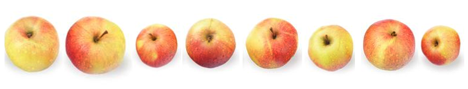

Чтобы увидеть медиану, мы должны ранжировать, или отсортировать, наш вектор по возрастанию:

```r
sort(apples)
```

```
## [1]  7.3  7.9  8.0  9.1  9.2  9.5  9.7 10.1
```

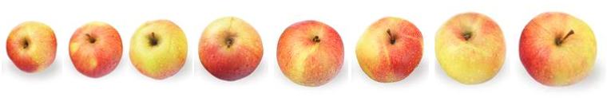

## Медиана

В ранжированном ряду медиана расположена так, что слева и справа от нее находится равное число измерений.

```r
sort(apples)
```

```
## [1]  7.3  7.9  8.0  9.1  9.2  9.5  9.7 10.1
```

Медиана находится в промежутке между значениями 9.1 и 9.2, т.е. 9.15

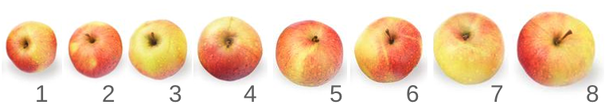

Проверим себя:

```r
median(apples)
```

```
## [1] 9.15
```

## Медиана: устойчивость к выбросам

Медиана обладает чрезвычайно приятным свойством – устойчивостью к выбросам.

Представим, что наше распределение пострадало от неаккуратности. Допустим сотрудник, которому мы поручили измерять яблоки, измерил также диаметр арбуза и записал этот результат вместе со всеми остальными.

```r
apples2 <- c(apples, 68) #Создадим вектор с новым значением
sort(apples2)
```

```
## [1]  7.3  7.9  8.0  9.1  9.2  9.5  9.7 10.1 68.0
```

Медиана теперь равна 9.2

```r
median(apples2)
```

```
## [1] 9.2
```

## Медиана: устойчивость к выбросам

Давайте для сравнения посмотрим на среднюю.

```r
mean(apples)
```

```
## [1] 8.85
```

```r
mean(apples2)
```

```
## [1] 15.4
```

Как видим, она не так благополучно пережила это вторжение. Единственное неверное измерение сбило ее из разряда довольно крупных яблок в область гигантских грейпфрутов.

## Квантили

Квантили — это значения, которые делят распределение на равные части.

Они называются по-разному в зависимости от числа частей.

Примеры квантилей:

- 2-квантиль — медиана
- 4-квантиль — квартиль
- 100-квантиль — перцентиль

## Квартили

Квартиль — частный случай квантиля.

Квартили делят распределение на **четыре** равные части, каждая из которых включает по 25% значений.

I квартиль отсекает как раз 25%. II — 50%. Это ни что иное, как медиана. III квартиль отсекает 75% значений.

Определим их с помощью команды `quantile`

```r
quantile(apples)
```

```
##    0%   25%   50%   75%  100%
##  7.30  7.97  9.15  9.55 10.10
```

Нам показали так же минимальную и максимальную величины.

## 5-number summary

Аналогичные значения, только со средней в качестве бесплатного приложения, возвращает и функция `summary`:

```r
summary(apples)
```

```
##    Min. 1st Qu.  Median    Mean 3rd Qu.    Max.
##    7.30    7.97    9.15    8.85    9.55   10.10
```

```r
summary(apples2)
```

```
##    Min. 1st Qu.  Median    Mean 3rd Qu.    Max.
##     7.3     8.0     9.2    15.4     9.7    68.0
```

## Персентили

Персентиль — это частный случай квантиля. Всего 100 персентилей.

Ничто не помешает нам узнать, например, какие значения отсекают 10% или 99% значений выборки. Подставим соответствующие аргументы:

```r
quantile(apples, probs = c(0.1, 0.99))
```

```
##   10%   99%
##  7.72 10.07
```

## Боксплот: 5-number summary на графике

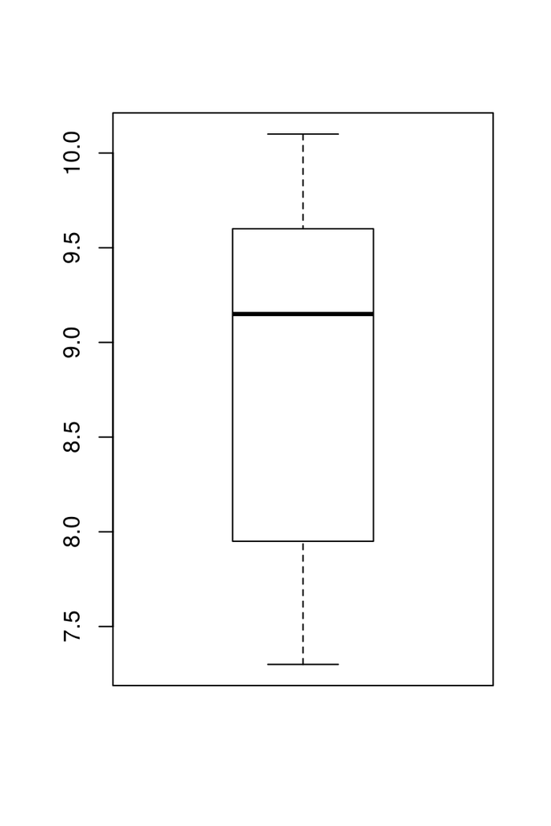

```r
boxplot(apples)
```

Отложим числа, характеризующие выборку, по оси Y:

- жирная линия в центре это медиана,
- нижняя и верхняя границы "коробочки" это I и III квантили,
- усы достигают минимального и максимального значений.

Расстояние между I и III квартилями (высота "коробочки") называется *интерквартильное расстояние*

Если в выборке присутствуют выбросы (значения, отстоящие от границ "коробочки" больше чем на 1.5 интерквартильных расстояния), то они будут изображены отдельными точками.

## Case study: диатомовые водоросли в желудках фильтраторов. Самостоятельная работа.

В морских сообществах встречаются два вида фильтраторов, один из которых любит селиться прямо на поверхности тела другого.

*Tegella armifera* это вид-хозяин. Он может жить как сам по себе, так и вместе с симбионтом.

*Loxosomella nordgardi* — вид-симбионт. Он практически никогда не встречается в одиночестве.

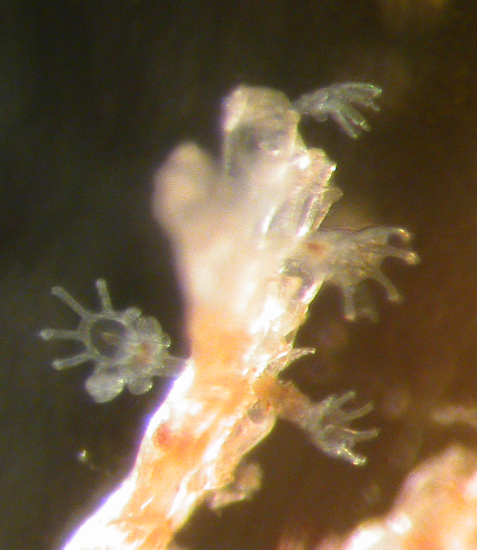

## Case study: диатомовые водоросли в желудках фильтраторов.

В файле `data\2.1_diatome_count.csv` даны количества диатомовых водорослей в желудках этих животных. Прочитаем эти данные и посмотрим на их структуру:

```r
diatoms <- read.table("data/2.1_diatome_count.csv",
                      header = T, sep = "")
head(diatoms)
```

```
##          sp count
## 1 host_free    10
## 2 host_free     0
## 3 host_free     1
## 4 host_free     0
## 5 host_free     2
## 6 host_free     0
```

В таблице 2 переменные: вид (sp) и число водорослей в желудке (count). В переменной sp есть три варианта значений: "host_free" "host_symbiont" и "symbiont"

Ваша задача рассчитать 5-number summary для количества диатомовых в желудках хозяев и симбионтов.

## Решение

```r
host_f <- diatoms$count[diatoms$sp == "host_free"]
host_s <- diatoms$count [diatoms$sp == "host_symbiont"]
symbiont <- diatoms$count [diatoms$sp == "symbiont"]
summary(host_f)
```

```
##    Min. 1st Qu.  Median    Mean 3rd Qu.    Max.    NA's
##     0.0     1.0     4.0     4.7     8.0    12.0       1
```

```r
summary(host_s)
```

```
##    Min. 1st Qu.  Median    Mean 3rd Qu.    Max.
##    0.00    0.25    4.50    5.35    8.00   20.00
```

```r
summary(symbiont)
```

```
##    Min. 1st Qu.  Median    Mean 3rd Qu.    Max.    NA's
##     0.0     0.0     1.0     1.5     2.0     7.0       4
```

## Боксплоты в ggplot2

Формат данных несколько сложен для человеческого глаза, зато очень подходит для ggplot.

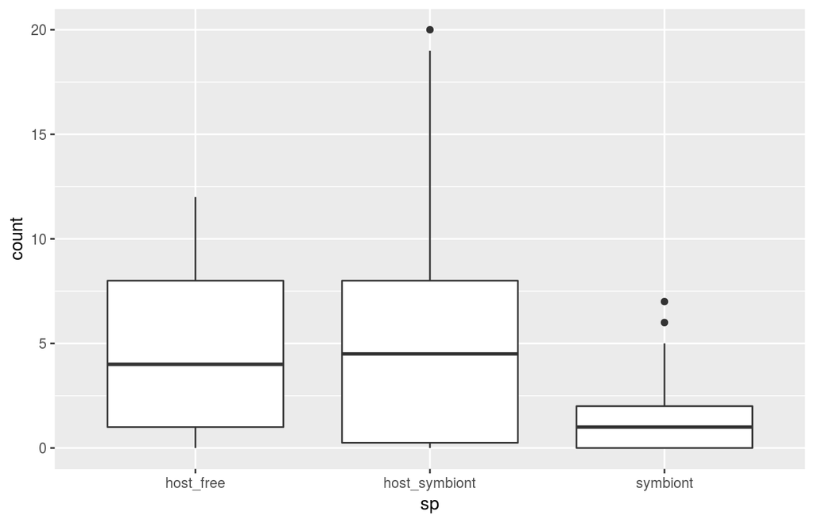

```r
library("ggplot2")
ggplot(data = diatoms, aes(y = count, x = sp)) + geom_boxplot()
```

## Квартили и боксплот: непараметрические характеристики выборки

Главный плюс, но так же и минус связки медиана + квантили это ее независимость от формы распределения.

Будь оно симметричным или с хвостом, 5-number summary опишет, а боксплот нарисует его без искажений. Однако, далеко на этих характеристиках не уедешь.

Бывают случаи, когда можно применять более специальные, но и более информативные характеристики.

## ЧАСТЬ 3. Нормальное распределение

## Все распределения равны, но некоторые равнее

Это непрерывное распределение, получаемое из мерных данных. Однако, многие распределения других типов тоже могут приближаться к нормальному.

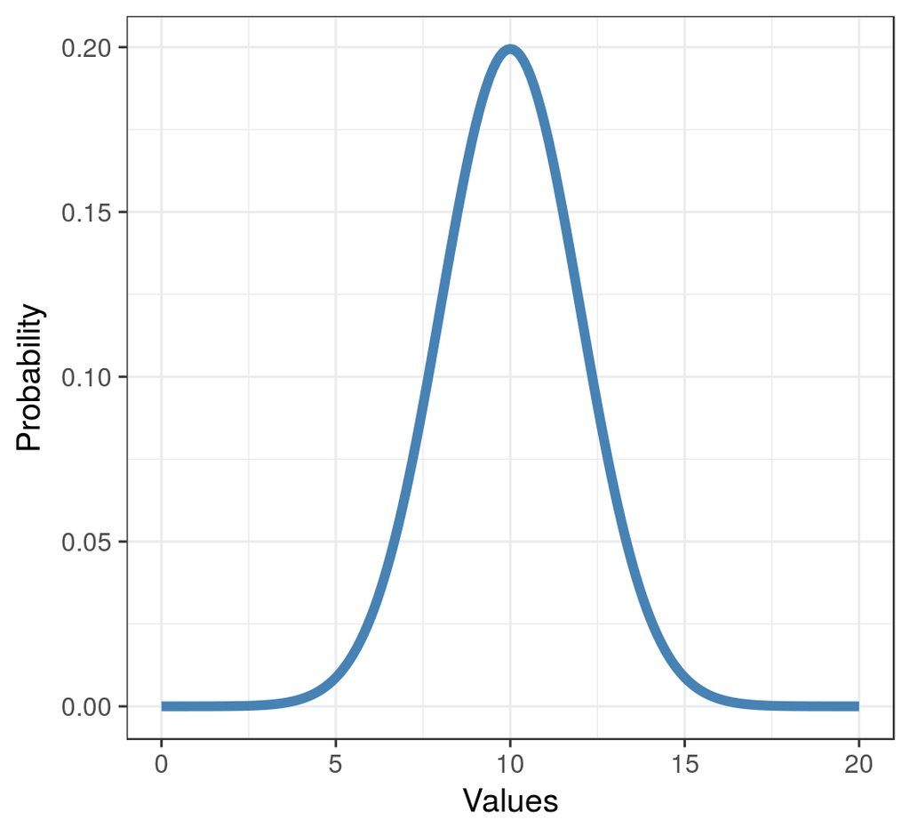

## Относительная частота и плотность вероятности

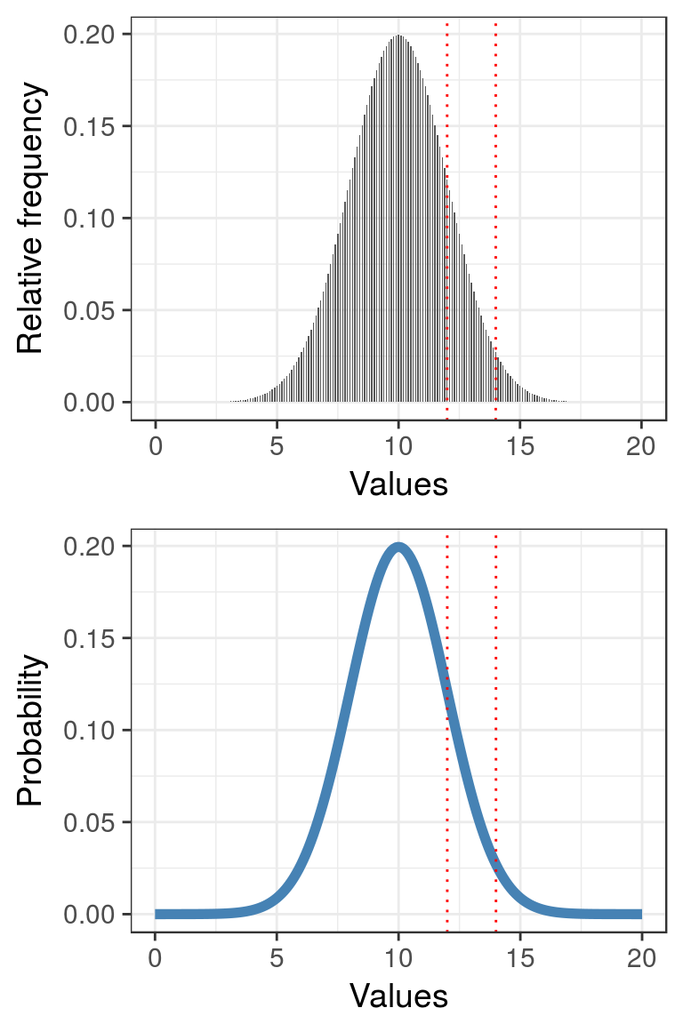

На оси Y может быть отложена относительная частота значений Х в эмпирическом распределении, или вероятность получить такие значения из теоретического распределения.

На оси Х отложены значения Х в интервале от 0 до 20, в действительности же кривая простирается от \(-\infty\) до \(+\infty\)

Площадь под кривой = 1. Интегрируя кривую на промежутке \((k,..,l)\), можно узнать вероятность встречи значений \((x_k,...x_l)\).

НО! Нельзя рассчитать вероятность одного значения \(X = x_k\), так как это точка, и под ней нет площади.

## Условия появления нормально распределенных признаков

- Множество факторов
- Наличие/отсутствие каждого фактора не зависит от остальных
- Эффекты факторов аддитивны и независимы
- Вклад каждого фактора в итоговую изменчивость одинаков

Что-то напоминает, не правда ли?

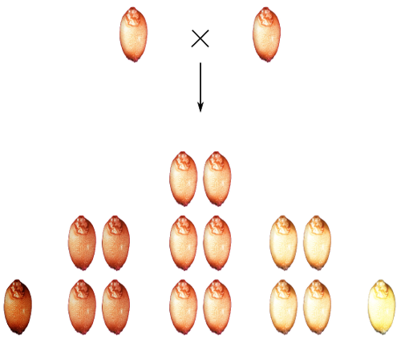

## Приятные особенности

Нормальных кривых бесконечно много, и их описывает заковыристая формула с двумя параметрами (\(\mu\) и \(\sigma\)).

\[p= \frac {1}{\sigma \sqrt{2 \pi}} e^{-\frac{(x-\mu)^2}{2\sigma^2}}\]

Достаточно знать эти два значения чтобы восстановить или смоделировать любое нормальное распределение.

Если:

- данные в выборке распределены нормально
- мы можем узнать или оценить параметры этого распределения

можно считать что выборка у нас в кармане! Нам больше не нужно знать результаты измерений, чтобы строить предположения о природе данных.

Так что же это за чудодейственные параметры? Средняя и стандартное отклонение конечно!

## ЧАСТЬ 4. Связка среднее + стандартное отклонение

## Центральная тенденция

### Арифметическое среднее

Формула

\[\bar{x}=\frac{\sum{x_i}}{n}\]

Рассчитаем вручную и проверим:

```r
mean_apple_diam <- sum(apples) / length(apples)
mean_apple_diam
```

```
## [1] 8.85
```

```r
round(mean_apple_diam,3) == round(mean(apples),3)
```

```
## [1] TRUE
```

## Меры разброса

### Девиата (отклонение)

Это разность между значением вариаты (измерения) и средней:

\[x_i - \bar{x}\]

```r
raw.deviates <- apples - mean(apples)
raw.deviates
```

```
## [1] -1.55  0.85  1.25  0.65 -0.85  0.35 -0.95  0.25
```

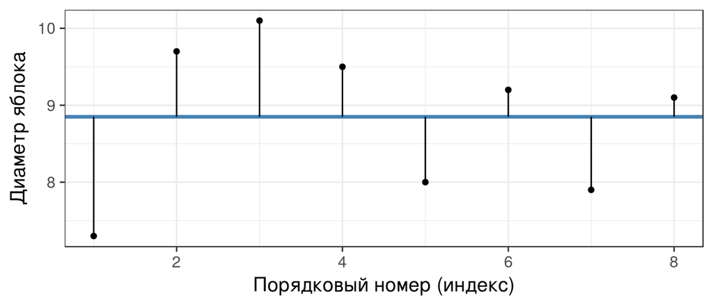

## Меры разброса

К сожалению мы не можем просто сложить все значения девиат и поделить их на объем выборки. Сумма девиат всегда будет равна нулю.

```r
round(sum(raw.deviates))
```

```
## [1] 0
```

### Путь 1: среднее отклонение = Average Deviation

Первый выход, который бросается в глаза, это использовать абсолютные значения

\[AD = \frac{\sum{\lvert x_i - \bar{x} \rvert}}{n}\]

```r
sum(abs(raw.deviates)) / length(apples)
```

## Меры разброса

### Путь 2: сумма квадратов = SS, Sum of Squares

Избавиться от знака девиаты можно не только с помощью модуля, но и возведя значение в квадрат.

\[SS = \sum{{(x_i - \bar{x})}^2}\]

```r
sum(raw.deviates^2)
```

## Меры разброса

### Дисперсия = MS, Mean Square, Variance

Если мы теперь поделим сумму квадратов на объем выборки, то получим дисперсию.

\[variance=\frac{\sum{(x_i - \bar{x})^2}}{n}= \frac{SS}{n}\]

```r
sum(raw.deviates^2) / length(apples)
```

### Среднеквадратичное/стандартное отклонение = Standard Deviation

Квадратный корень из дисперсии позволит вернуться к исходным единицам измерения

\[SD=\sqrt{\frac{\sum{(x_i - \bar{x})^2}}{n}} = \sqrt{variance}\]

```r
sqrt(sum(raw.deviates^2) / length(apples))
```

## Особенности применения связки

- только вместе,
- чувствительны к выбросам,
- плохо работают с несимметричными распределениями.

## Сравните разброс в выборках

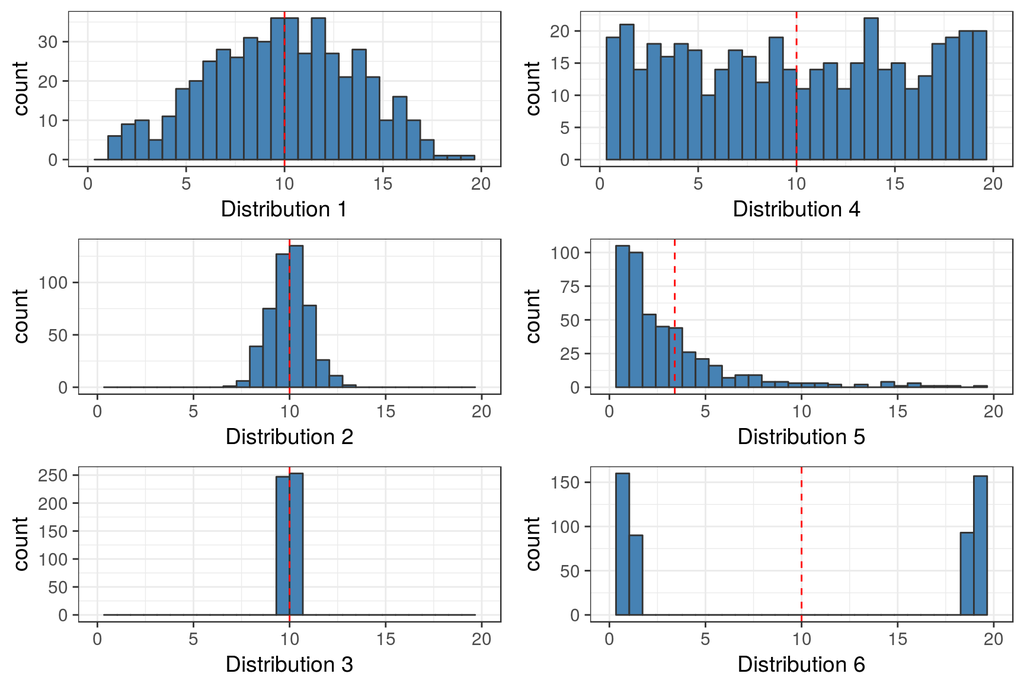

## Проверим себя

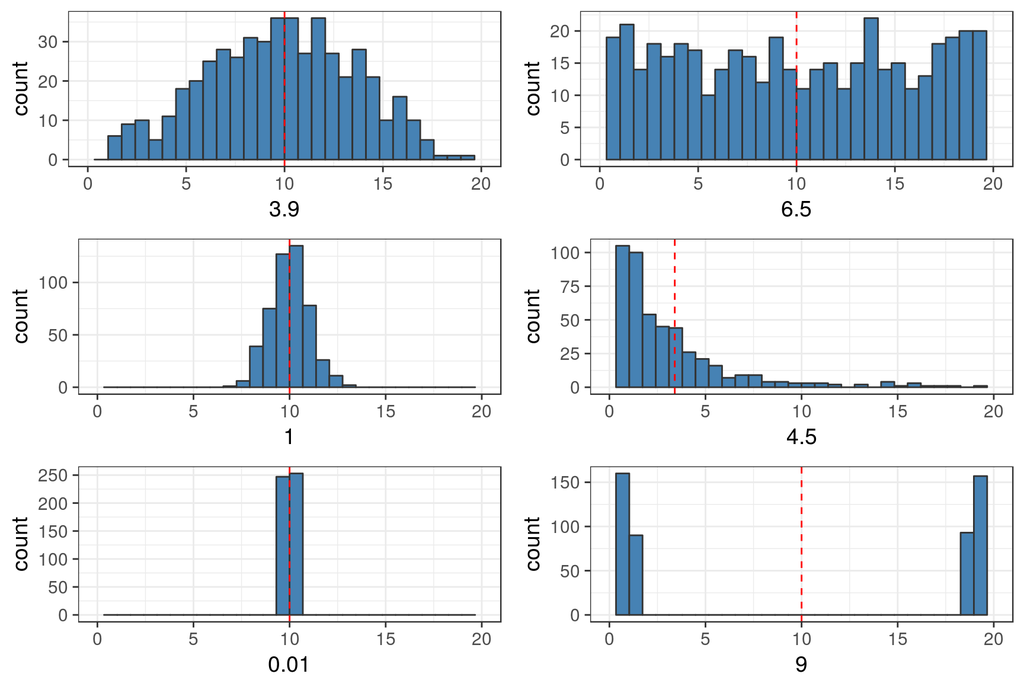

## Задание

Из пяти положительных чисел создайте выборку со средней = 10 и медианой = 7

## Решение 1

В выборке с медианой = 7 и n = 5, мы точно знаем: (а) одно из значений должно быть равно 7, (б) два значения должны быть меньше, и два — больше 7.

Создадим вектор, в котором одно значение задано, а три других просто придумаем:

```r
example <- c(2, 5, 7, 10)
```

Среднее это сумма всех значений выборки, поделенная на ее объем. Умножив среднюю на 5 получим сумму всех значений.

Определим недостающее и проверим себя:

```r
10 * 5 - sum(example)
```

```
## [1] 26
```

```r
example <- c(2, 5, 7, 10, 26) #перезапишем вектор
mean(example)
```

```
## [1] 10
```

## ЧАСТЬ 5. От статистик к параметрам.

## Выборка и генеральная совокупность

### Статистики

- описывают выборки
- их обозначают латинскими буквами: \(М\), \(s^2\).

### Параметры

- описывают генеральную совокупность
- их обозначают греческими буквами: \(\mu\), \(\sigma^2\)

С помощью выборочных статистик мы стремимся описать популяционные параметры.

## Степени свободы в стандартном отклонении

Среднеквадратичное отклонение, которое мы только что сконструировали, верно описывает выборку, но не годится для генеральной совокупности, так как недооценивает ее истинное разнообразие.

Чтобы это исправить, в знаменатель нужно внести поправку, из объема выборки превратить его в степень свободы.

### Дисперсия — \(s^2\) (выборочная оценка параметра \(\sigma^2\))

\[s^2=\frac{\sum{(x_i - \bar{x})^2}}{n-1}\]

### Стандартное отклонение — \(s\) или SD (выборочная оценка параметра \(\sigma\))

\[SD=\sqrt{\frac{\sum{(x_i - \bar{x})^2}}{n-1}}\]

## Степени свободы в стандартном отклонении

\[SD=\sqrt{\frac{\sum{(x_i - \bar{x})^2}}{n-1}}\]

```r
sqrt(sum(raw.deviates^2) / (length(apples) - 1))
```

[output not shown]

Сравним с результатом команды `sd()`

```r
sd(apples)
```

[output not shown]

При расчете стандартного отклонения R автоматически вносит поправку и использует степени свободы, а не "сырой" объем выборки.

## Ошибка среднего, SEM

Имея дело с выборками и стремясь распространить то, что мы узнали, на всю генеральную совокупность, исследователю к лицу некоторая скромность.

Наша выборка — лишь одна из множества возможных выборок, берущих начало из некой генеральной совокупности. Значения попадают в выборки случайно, а потому не одинаковыми будут и итоговые выборочные статистики.

Каждая из них, хотя и будет описывать популяционный параметр, имеет шанс быть неверной.

## Модель генеральной совокупности

Давайте для наших экспериментов создадим генеральную совокупность с параметрами \(\mu = 50\) и \(\sigma = 7\).

Вот график ее частотного распределения.

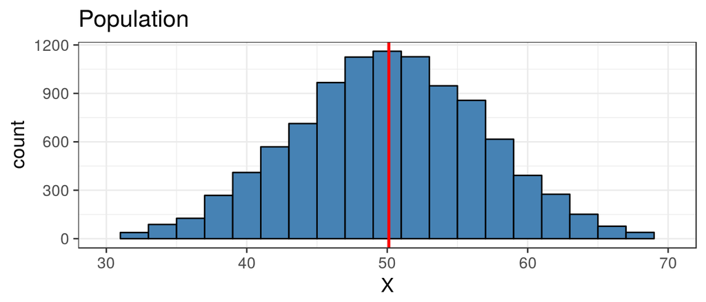

## Возьмем выборку из этой генеральной совокупности

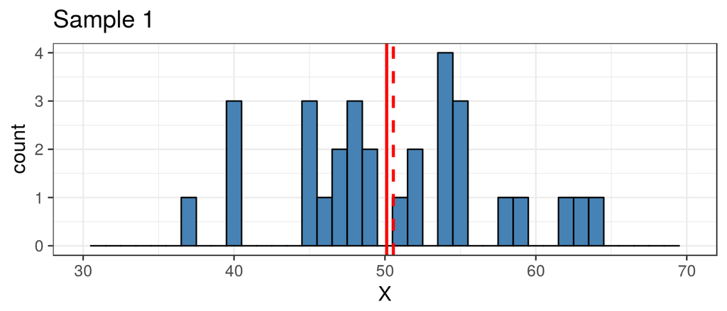

## В разных выборках средние значения будут отличаться.

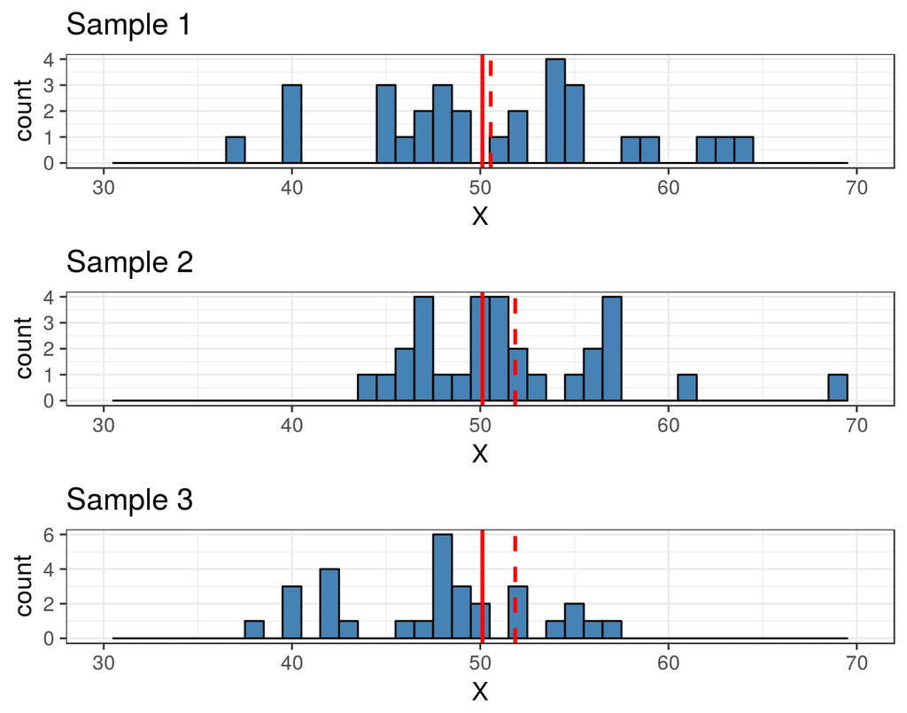

## Что будет со средними, если взять много выборок?

Давайте возьмем много-много выборок, вычислим для каждой выборочное среднее и построим распределение этих выборочных средних.

**Выборочные средние нормально распределены с параметрами** \(\mu\) и \(SD _\bar{x}\)

**Среднее значение выборочных средних стремится к среднему в генеральной совокупности**

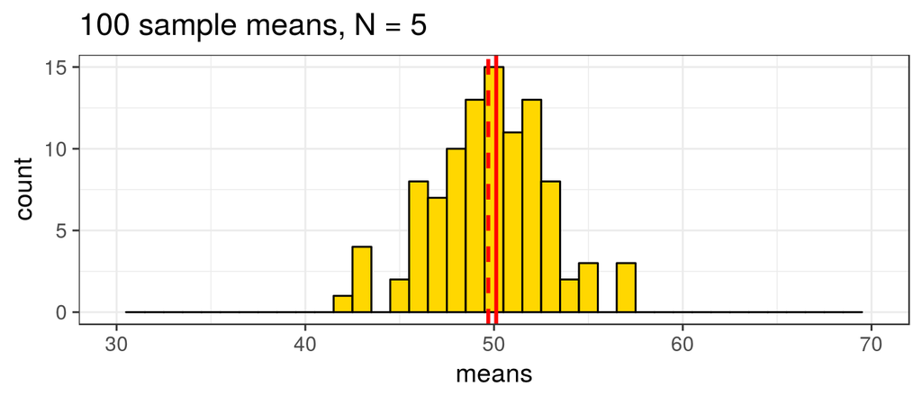

## Чем больше объем выборок, тем точнее оценка среднего в генеральной совокупности

\[SE _\bar{x} = \sigma / \sqrt{N}\]

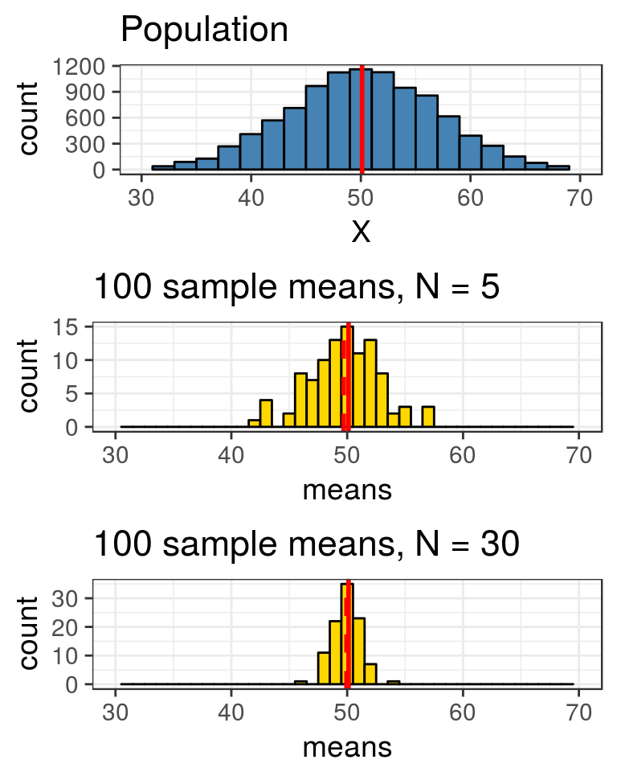

То есть, чем больше будет объем выборок, тем меньше будет эта стандартная ошибка, и тем точнее мы оценим (параметрическое) среднее в генеральной совокупности.

## SD vs SE

Выборку должны характеризовать центральная тенденция (средняя) и мера разброса.

Стандартное отклонение описыват непосредственно выборку, т.е. отличия значений от выборочного среднего, а значит является более хорошей описательной статистикой, чем стандартное отклонение (=стандартная ошибка) среднего.

Поэтому лучше характеризовать данные в формате

\[Mean \pm SD (N)\]

а не

\[Mean \pm SE (N)\]

## Take home messages

- Описательные статистики ходят только в связке.
- Выбирая между медианой и средней, учитывайте природу данных.